# Project 3: Value Skills in Data Science

Teams 5 - Leticia Salazar,Victoria McEleney, Javier Pajuelo,Trang Do,Cassandra Boylan

2021-10-19

```r
library(tidyverse)
library(openintro)
```

# **Project – Data Science Skills**

### We install our libraries

```r
#Load Libraries
library(tidyr)
library(dplyr)
library(textdata)
library(knitr)
library(tidyverse)
library(wordcloud)
library(RColorBrewer)
library(ggplot2)
library(reshape2)
library(ggthemes)
library(png)
library(digest)
library(DBI)
library(kableExtra)
```

# Data source

This discussion bases on dataset from https://data.world/

# Loading the data from GitHub

```r
jobspikr_url = 'https://raw.githubusercontent.com/quaere1verum/sps_public/master/data607-001/assignments/project3/data_scientist_united_states_job_postings_jobspikr.csv'

jobspikr_small_url = 'https://raw.githubusercontent.com/quaere1verum/sps_public/master/data607-001/assignments/project3/data_scientist_jobspikr_10152021_merged.csv'

jobspikr_data <- read_csv(jobspikr_small_url)
glimpse(jobspikr_data )
```

```
## Rows: 807
## Columns: 42
## $ crawl_timestamp             <chr> "2021-10-05 23:22:15 +0000", "2021-10-01 2…
## $ url                         <chr> "https://www.simplyhired.com/job/K22En1QML…
## $ job_title                   <chr> "Data Scientist - IoT Innovation & Edge Co…
## $ category                    <chr> NA, "Full-time", "Contract", NA, "Full-tim…
## $ company_name                <chr> "McDonald's Corporate", "Eurofins USA BioP…
## $ city                        <chr> "Romeoville", "Lancaster", "Chicago", "New…
## $ state                       <chr> "IL", "PA", "IL", "NJ", "TX", "GA", "CA", …
## $ country                     <chr> "United States", "United States", "United …
## $ inferred_city               <chr> "Romeoville", "Lancaster", "Chicago", "New…
## $ inferred_state              <chr> "Illinois", "Pennsylvania", "Illinois", "N…
## $ inferred_country            <chr> "United states", "United states", "United …
## $ post_date                   <chr> "10/5/2021", "10/1/2021", "10/6/2021", "10…
## $ job_description             <chr> "Refer A Friend Company Description We are…
```

[output cut: 29 more lines]

```r
jobspikr_data $state[toupper(jobspikr_data $state)=="CALIFORNIA"]<-"CA"
jobspikr_data $state[toupper(jobspikr_data $state)=="NEW YORK"]<-"NY"
jobspikr_data $state[toupper(jobspikr_data $state)=="COLORADO"]<-"CO"
jobspikr_data $state[toupper(jobspikr_data $state)=="MARYLAND"]<-"MD"
jobspikr_data $state[toupper(jobspikr_data $state)=="ILLINOIS"]<-"IL"
jobspikr_data $state[is.na(jobspikr_data $state)|jobspikr_data $state==""]<-"unknown"

jobspikr_data $inferred_salary_time_unit[jobspikr_data $inferred_salary_time_unit==""]<-"unknown"
```

# Create Tables & write data to SQL

```r
db <- 'project3'  #provide the name of your db
host_db <- 'localhost'
db_port <- '5432'
db_user <- 'postgres'
db_password <- 'data607'
con <- dbConnect(RPostgres::Postgres(), dbname = db, host=host_db, port=db_port, user=db_user, password=db_password)

test<-strsplit(jobspikr_data $inferred_skills, split = "\\|")

skillset <-data.frame(skill=character())
s <-length(test)

for (i in 1:s){
  for (j in 1:lengths(test[i])){
    rows<-data.frame(skill=test[[i]][j])
    skillset <-rbind(skillset,rows)
  }
}

skill_types<-skillset %>% select(skill) %>%
      group_by(skill)%>%
      summarise(n=n())

skill_types<-skill_types %>% mutate(skillid=sapply(skill_types$skill, digest, algo="md5"))

skill_types<-skill_types %>% select(skillid,skill)
dbWriteTable(con,'skill_types',skill_types,overwrite=TRUE)

# --------------
skill_company <-data.frame(company=character(),state=character())

test <-jobspikr_data  %>% select (company_name,inferred_skills,state)%>%
    filter(inferred_skills!="")

datarow<-nrow(test)

for (i in 1:datarow){
  infer_byrow <-c(skill=strsplit(test[[i,2]], split = "\\|"))
  rows<-data.frame(skill=infer_byrow,company=test[[i,1]],state=test[[i,3]])
  skill_company <-rbind(skill_company,rows)
}

companies<-skill_company %>%
  select(company)%>%group_by(company)%>%
  summarise(n=n())

companies<-as.data.frame(companies %>% mutate(companyid=sapply(companies$company, digest, algo="md5")))

companies<-companies %>% select(companyid,company)
dbWriteTable(con,'companies',companies,overwrite=TRUE)

job_df <-data.frame()
tempskill_company <- data.frame()
for (i in 1:length(companies$company)){
  test <- jobspikr_data  %>%
    filter(company_name==companies$company[[i]])%>%
    mutate(companyid=companies$companyid[[i]])
  job_df <- rbind(job_df,test)

  tmp <-skill_company %>%
    filter(company==companies$company[[i]])%>%
    mutate(companyid=companies$companyid[[i]])
  tempskill_company <- rbind(tempskill_company,tmp)
}

dbWriteTable(con,'jobs',job_df,overwrite=TRUE)

skill_company_table<-data_frame()
for (i in 1:length(skill_types$skill)){
  tmp <-tempskill_company %>%
    filter(skill==skill_types$skill[[i]])%>%
    mutate(skillid=skill_types$skillid[[i]])
  skill_company_table <- rbind(skill_company_table,tmp)
}

dbWriteTable(con,'Skills_companies',skill_company_table,overwrite=TRUE)
```

# Highest pay based on yearly salary data

```r
salary_jobtitle<- jobspikr_data %>%
  select(job_title,inferred_salary_time_unit,inferred_salary_currency,inferred_salary_to)%>%
  filter(inferred_salary_time_unit == 'yearly', inferred_salary_currency=='USD')%>%
  group_by(job_title)%>%
  summarise(max=max(inferred_salary_to))%>%
  arrange(desc(max))

top_n(salary_jobtitle%>% mutate(Salary=format(salary_jobtitle$max,big.mark=",")),10) %>%
   select(job_title,Salary)%>%
   knitr::kable(caption="Salary Table")%>%
   kable_styling(bootstrap_options = c("bordered","striped"))%>%
   kable_paper(html_font="arial",font_size=10,full_width = F)
```

Salary Table

| job_title | Salary |
| --- | --- |
| Staff Data Scientist - Match Recommendations | 270,000 |
| Data Scientist | 255,000 |
| Senior Data Scientist | 225,000 |
| Lead Data Scientist | 210,000 |
| Principal Data Scientist-Marketing Attribution | 210,000 |
| Principal Data Scientist | 200,000 |
| Senior Data Scientist - Cancer Target Discovery | 200,000 |
| Senior Data Scientist/ML Engineer | 200,000 |
| Senior Developer/Data Scientist | 200,000 |
| Applied Data Scientist II | 190,000 |
| Data Scientist, Product Analytics - Notifications Ranking | 190,000 |
| Lead Data Scientist - Quantitative Analytics Spec 4 | 190,000 |
| PRINCIPAL DATA SCIENTIST | 190,000 |

# Plots

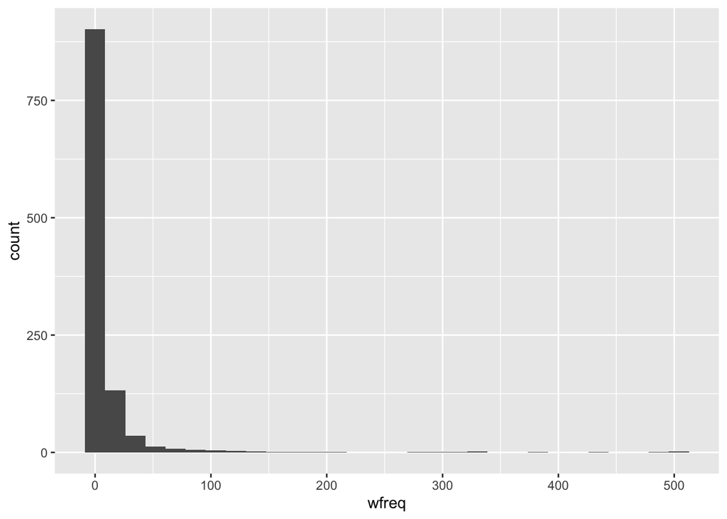

```r
word_freq<- skillset %>% group_by(skill)%>%
  summarise(wfreq=n())
# Plots #
ggplot(word_freq, aes(wfreq),horizontal = TRUE) +
  geom_histogram()
```

[figure not shown]

```r
ggplot(skillset,aes(skill))+
  geom_bar()
```

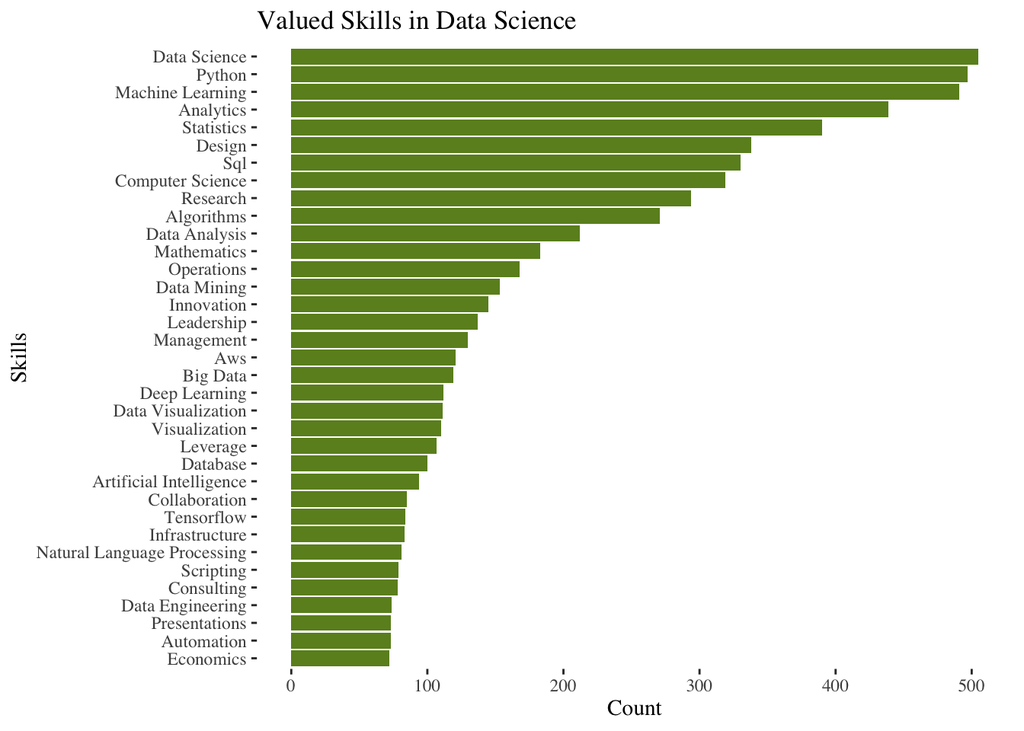

```r
ggplot(top_n(word_freq,35), aes(x=reorder(skill,wfreq),y = wfreq)) +
  geom_bar(stat='identity',fill="olivedrab")+
  coord_flip()+
  ylab("Count")+
  xlab("Skills")+
  theme_tufte()+
  ggtitle("Valued Skills in Data Science")
```

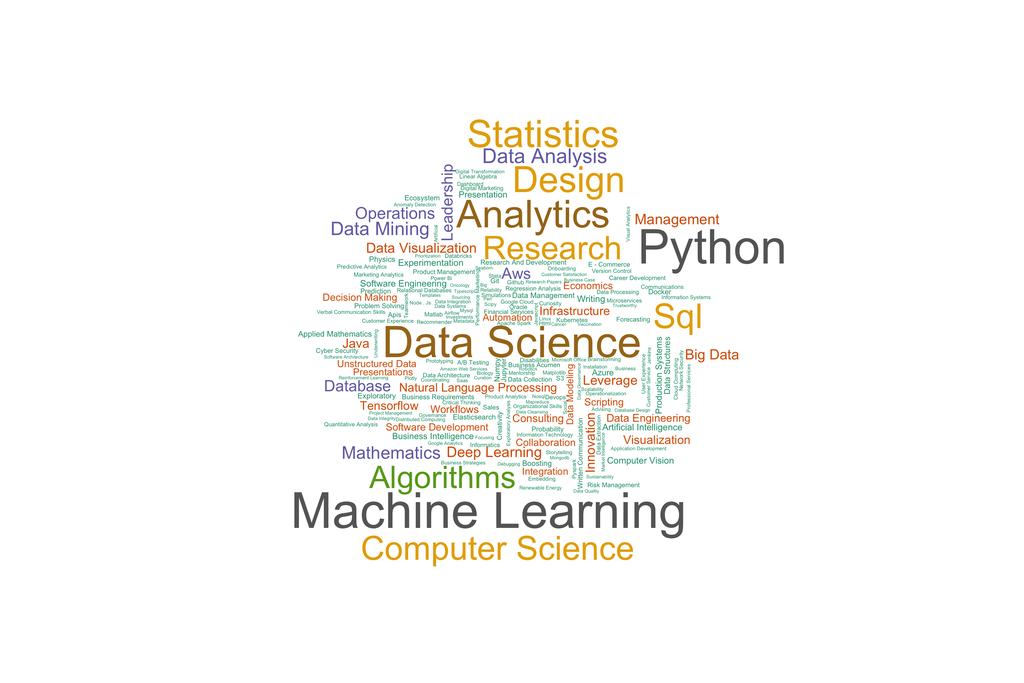

```r
# Word Cloud #
png("wordcloud.png",width = 12, height = 8,units = "in", res=300)
par(mar=rep(0,4))
set.seed(10142021)
word_freq <- word_freq %>% arrange(desc(wfreq))
wordcloud(word_freq$skill,freq = word_freq$wfreq,scale=c(3.5,0.25),
          colors=brewer.pal(8,"Dark2"))
wordcloud_pic <- '/Users/admin/Downloads/wordcloud.png'
include_graphics(wordcloud_pic)
```

# Required Skills by State ex: (“CA”,“NY”,“TX”,“NE”,“FL”,“NJ”,“MA”)

```r
company_state <- skill_company_table %>% select(companyid,state)%>%
  group_by(companyid,state) %>%
  summarise(skill_count=n())
```

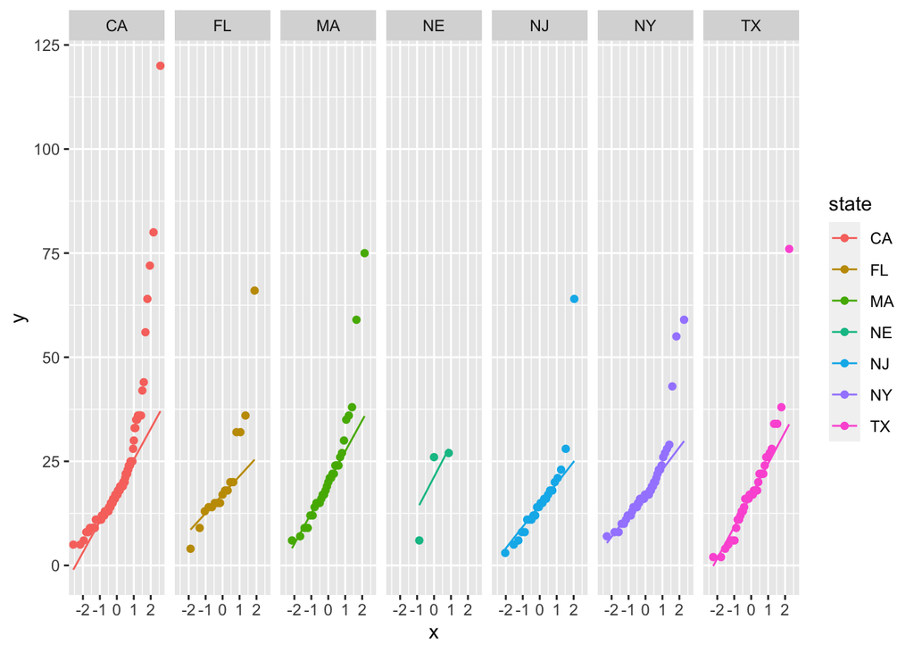

```r
company_state <- company_state %>% mutate(ratio= skill_count/sum(skill_count))

ggplot(company_state %>% filter (state %in% c("CA","NY","TX","NE","FL","NJ","MA")) , aes(sample=skill_count))+
  stat_qq(aes(color =state))+
  stat_qq_line(aes(color = state))+
  facet_grid(~state)
```

# Let see LM function

```r
#------- Ratio to whole dataset
company_state <- skill_company_table %>% select(companyid,state)%>%
  group_by(companyid,state) %>%
  summarise(skill_count=n())
```

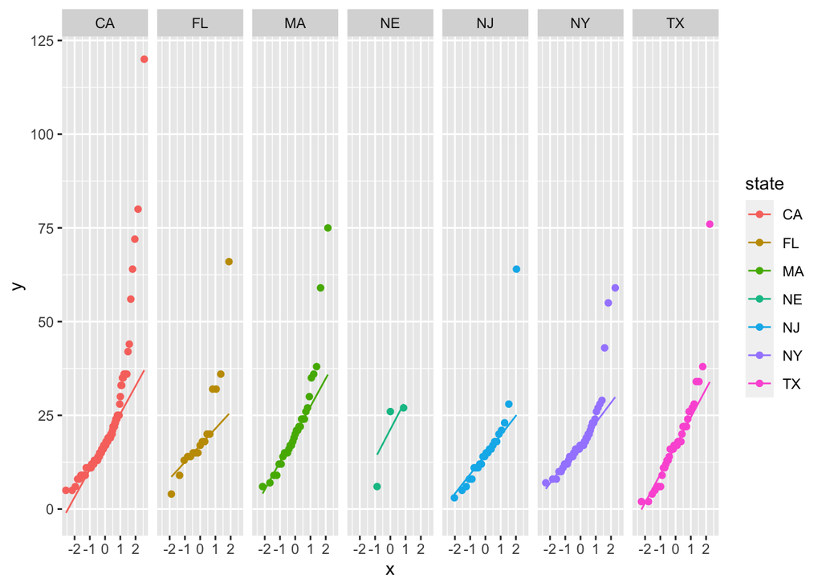

```r
company_state <- company_state %>% mutate(ratio= skill_count/sum(skill_count))

ggplot(company_state %>% filter (state %in% c("CA","NY","TX","NE","FL","NJ","MA")) , aes(sample=skill_count))+
  stat_qq(aes(color =state))+
  stat_qq_line(aes(color = state))+
  facet_grid(~state)
```

```r
lm_company_state <- lm(ratio~state,data=company_state)
summary(lm_company_state)
```

```
##
## Call:
## lm(formula = ratio ~ state, data = company_state)
##
## Residuals:
##     Min      1Q  Median      3Q     Max
## -0.8424 -0.2497  0.1391  0.2354  0.4930
##
## Coefficients:
##                     Estimate Std. Error t value Pr(>|t|)
## (Intercept)          0.63705    0.17333   3.675  0.00026 ***
## stateAZ             -0.05107    0.22377  -0.228  0.81956
## stateCA              0.21927    0.17684   1.240  0.21550
## stateCO             -0.01050    0.20832  -0.050  0.95980
## stateConnecticut     0.36295    0.38759   0.936  0.34944
## stateCT              0.16616    0.21728   0.765  0.44477
## stateDC              0.04327    0.18780   0.230  0.81788
## stateDE              0.26073    0.26477   0.985  0.32517
## stateFL              0.14051    0.19265   0.729  0.46610
## stateGA              0.08622    0.18418   0.468  0.63985
## stateGeorgia         0.06471    0.26477   0.244  0.80702
## stateHI              0.36295    0.38759   0.936  0.34944
## stateIA              0.15462    0.24513   0.631  0.52845
## stateID             -0.09187    0.30022  -0.306  0.75972
## stateIL              0.15777    0.18573   0.849  0.39599
## stateIL 61265        0.24530    0.38759   0.633  0.52705
## stateIN              0.12801    0.22377   0.572  0.56750
## stateKS              0.36295    0.38759   0.936  0.34944
## stateKY              0.05163    0.26477   0.195  0.84546
## stateLOUISIANA      -0.55630    0.38759  -1.435  0.15175
## stateMA              0.12750    0.18418   0.692  0.48906
## stateMassachusetts  -0.49979    0.38759  -1.290  0.19774
## stateMD              0.22994    0.18722   1.228  0.21988
## stateME             -0.13705    0.38759  -0.354  0.72377
## stateMI              0.19152    0.23255   0.824  0.41052
## stateMinnesota       0.36295    0.38759   0.936  0.34944
## stateMN             -0.01221    0.20241  -0.060  0.95190
## stateMO              0.15538    0.20241   0.768  0.44302
## stateMULTIPLE       -0.18984    0.38759  -0.490  0.62446
## stateNC             -0.05835    0.19163  -0.304  0.76086
```

[output cut: 18 more lines]

```
## stateTX              0.03395    0.18179   0.187  0.85194
## stateunknown         0.06053    0.20509   0.295  0.76801
## stateUT              0.18050    0.23255   0.776  0.43798
## stateVA              0.22388    0.18087   1.238  0.21630
## stateVirginia       -0.16470    0.30022  -0.549  0.58351
## stateWA              0.04174    0.18722   0.223  0.82364
## stateWashington     -0.53179    0.38759  -1.372  0.17059
## stateWI              0.36295    0.24513   1.481  0.13925
## stateWV              0.36295    0.38759   0.936  0.34944
## ---
## Signif. codes:  0 '***' 0.001 '**' 0.01 '*' 0.05 '.' 0.1 ' ' 1
##
## Residual standard error: 0.3467 on 573 degrees of freedom
## Multiple R-squared:  0.1067, Adjusted R-squared:  0.01943
## F-statistic: 1.223 on 56 and 573 DF,  p-value: 0.1366
```

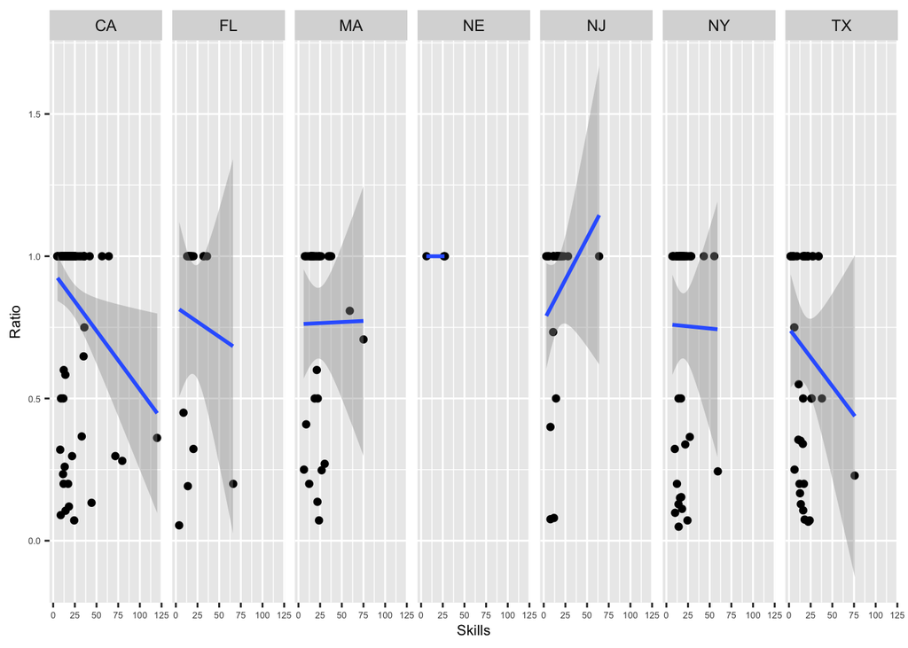

```r
lmplot<- company_state %>% filter (state %in% c("CA","NY","TX","NE","FL","NJ","MA"))

ggplot(data = lmplot, aes(x = skill_count, y = ratio)) +
  geom_jitter() +
  geom_smooth(method = "lm")+
  facet_grid(~state)+
  xlab("Skills")+
  ylab("Ratio")+
  theme(axis.text.x = element_text(size=5),
        axis.text.y = element_text(size=5),
        axis.title.x = element_text(size = 8),
        axis.title.y = element_text(size = 8))
```

```r
#------- Ratio by State
company_state <- company_state %>%
  group_by(state)%>%
  mutate(ratio= skill_count/sum(skill_count))

lm_company_state <- lm(ratio~state,data=company_state)
summary(lm_company_state)
```

```
##
## Call:
## lm(formula = ratio ~ state, data = company_state)
##
## Residuals:
##      Min       1Q   Median       3Q      Max
## -0.31250 -0.01317 -0.00302  0.00656  0.44444
##
## Coefficients:
##                       Estimate Std. Error t value Pr(>|t|)
## (Intercept)          2.500e-01  3.296e-02   7.585 1.35e-13 ***
## stateAZ             -8.333e-02  4.255e-02  -1.959 0.050655 .
## stateCA             -2.398e-01  3.362e-02  -7.132 3.00e-12 ***
## stateCO             -1.389e-01  3.961e-02  -3.506 0.000490 ***
## stateConnecticut     7.500e-01  7.370e-02  10.177  < 2e-16 ***
## stateCT             -1.071e-01  4.132e-02  -2.593 0.009750 **
## stateDC             -2.065e-01  3.571e-02  -5.783 1.20e-08 ***
## stateDE              8.333e-02  5.034e-02   1.655 0.098422 .
## stateFL             -1.912e-01  3.663e-02  -5.219 2.52e-07 ***
## stateGA             -2.177e-01  3.502e-02  -6.218 9.73e-10 ***
## stateGeorgia         8.333e-02  5.034e-02   1.655 0.098422 .
## stateHI              7.500e-01  7.370e-02  10.177  < 2e-16 ***
## stateIA              1.552e-15  4.661e-02   0.000 1.000000
## stateID              2.500e-01  5.709e-02   4.379 1.42e-05 ***
## stateIL             -2.130e-01  3.532e-02  -6.030 2.94e-09 ***
## stateIL 61265        7.500e-01  7.370e-02  10.177  < 2e-16 ***
## stateIN             -8.333e-02  4.255e-02  -1.959 0.050655 .
## stateKS              7.500e-01  7.370e-02  10.177  < 2e-16 ***
## stateKY              8.333e-02  5.034e-02   1.655 0.098422 .
## stateLOUISIANA       7.500e-01  7.370e-02  10.177  < 2e-16 ***
## stateMA             -2.177e-01  3.502e-02  -6.218 9.73e-10 ***
## stateMassachusetts   7.500e-01  7.370e-02  10.177  < 2e-16 ***
## stateMD             -2.083e-01  3.560e-02  -5.852 8.17e-09 ***
## stateME              7.500e-01  7.370e-02  10.177  < 2e-16 ***
## stateMI             -5.000e-02  4.422e-02  -1.131 0.258634
## stateMinnesota       7.500e-01  7.370e-02  10.177  < 2e-16 ***
## stateMN             -1.591e-01  3.849e-02  -4.134 4.11e-05 ***
## stateMO             -1.591e-01  3.849e-02  -4.134 4.11e-05 ***
## stateMULTIPLE        7.500e-01  7.370e-02  10.177  < 2e-16 ***
## stateNC             -1.944e-01  3.644e-02  -5.336 1.37e-07 ***
```

[output cut: 18 more lines]

```
## stateTX             -2.250e-01  3.457e-02  -6.509 1.65e-10 ***
## stateunknown        -1.500e-01  3.900e-02  -3.846 0.000133 ***
## stateUT             -5.000e-02  4.422e-02  -1.131 0.258634
## stateVA             -2.278e-01  3.439e-02  -6.623 8.12e-11 ***
## stateVirginia        2.500e-01  5.709e-02   4.379 1.42e-05 ***
## stateWA             -2.083e-01  3.560e-02  -5.852 8.17e-09 ***
## stateWashington      7.500e-01  7.370e-02  10.177  < 2e-16 ***
## stateWI              4.841e-16  4.661e-02   0.000 1.000000
## stateWV              7.500e-01  7.370e-02  10.177  < 2e-16 ***
## ---
## Signif. codes:  0 '***' 0.001 '**' 0.01 '*' 0.05 '.' 0.1 ' ' 1
##
## Residual standard error: 0.06592 on 573 degrees of freedom
## Multiple R-squared:  0.8687, Adjusted R-squared:  0.8559
## F-statistic: 67.71 on 56 and 573 DF,  p-value: < 2.2e-16
```

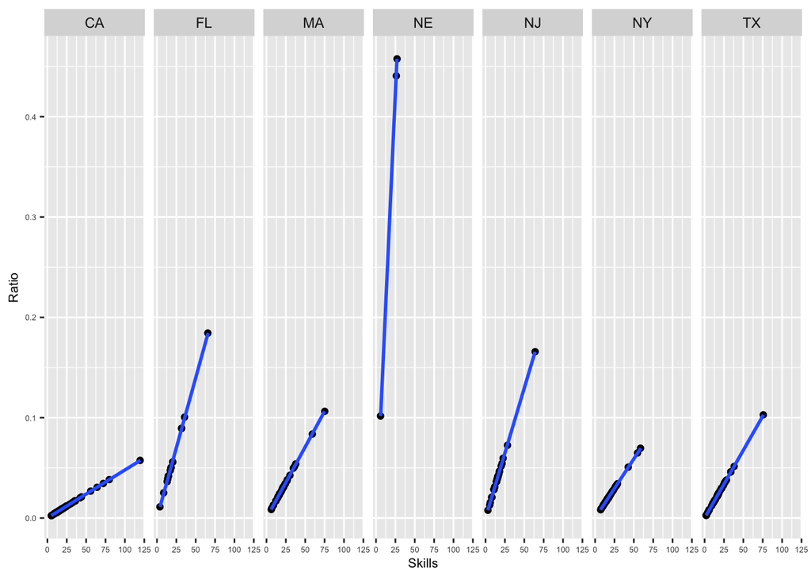

```r
lmplot<- company_state %>% filter (state %in% c("CA","NY","TX","NE","FL","NJ","MA"))

ggplot(data = lmplot, aes(x = skill_count, y = ratio)) +
  geom_jitter() +
  geom_smooth(method = "lm")+
  facet_grid(~state)+
  xlab("Skills")+
  ylab("Ratio")+
  theme(axis.text.x = element_text(size=5),
        axis.text.y = element_text(size=5),
        axis.title.x = element_text(size = 8),
        axis.title.y = element_text(size = 8))
```

# Scrap data from Indeed website & sample results

Codes in detail as below https://github.com/quaere1verum/sps_public/blob/master/data607-001/assignments/project3/Extract_From_Indeed.Rmd

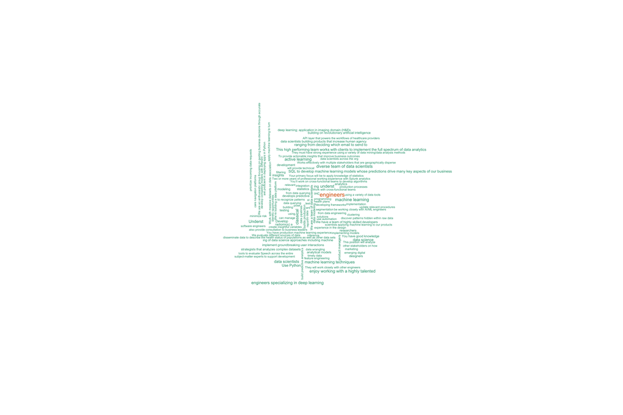

```r
csvfile <- "https://raw.githubusercontent.com/quaere1verum/sps_public/master/data607-001/assignments/project3/csv/Indeed_data.csv"

Indeed <- read.csv(csvfile)

Indeed <-Indeed %>% slice_max(Indeed$job.description, n = 300)

Indeed$job.description<-str_replace_all(Indeed$job.description, "\\n", " and ")
Indeed$job.description<-str_replace_all(Indeed$job.description,"\\.","")
Indeed$job.description<-str_replace_all(Indeed$job.description,":","")
Indeed$job.description<-str_replace_all(Indeed$job.description,"You will","")
Indeed$job.description<-str_replace_all(Indeed$job.description,"You'll","")
Indeed$job.description<-gsub("[…]","",Indeed$job.description)

words<-data.frame(w=character())
words<-strsplit(Indeed$job.description,split = "and|,")

skillset <-data.frame(skill=character())
s <-length(words)

for (i in 1:s){
  for (j in 1:lengths(words[i])){
    rows<-data.frame(skill=str_trim(words[[i]][j]))
    skillset <-rbind(skillset,rows)
  }
}

word_freq<- skillset %>% group_by(skill)%>%
  summarise(wfreq=n())

png("Indeed_wordcloud.png",width = 12, height = 8,units = "in", res=300)
par(mar=rep(0,4))
set.seed(10142021)
word_freq <- word_freq %>% arrange(desc(wfreq))

#set.seed
set.seed(87)
wordcloud(word_freq$skill,freq = word_freq$wfreq,scale=c(3.5, 0.25),
          colors=brewer.pal(8,"Dark2"))

wordcloud_pic <- '/Users/admin/Project 3 Presentation/Indeed_wordcloud.png'
include_graphics(wordcloud_pic)
```

# Conclusion